# Credit Card Users Churn Prediction

## Problem Statement

### Business Context

The Thera bank recently saw a steep decline in the number of users of their credit card, credit cards are a good source of income for banks because of different kinds of fees charged by the banks like annual fees, balance transfer fees, and cash advance fees, late payment fees, foreign transaction fees, and others. Some fees are charged to every user irrespective of usage, while others are charged under specified circumstances.

Customers’ leaving credit cards services would lead bank to loss, so the bank wants to analyze the data of customers and identify the customers who will leave their credit card services and reason for same – so that bank could improve upon those areas

You as a Data scientist at Thera bank need to come up with a classification model that will help the bank improve its services so that customers do not renounce their credit cards

### Data Description

- CLIENTNUM: Client number. Unique identifier for the customer holding the account
- Attrition_Flag: Internal event (customer activity) variable - if the account is closed then "Attrited Customer" else "Existing Customer"
- Customer_Age: Age in Years
- Gender: Gender of the account holder
- Dependent_count: Number of dependents
- Education_Level: Educational Qualification of the account holder - Graduate, High School, Unknown, Uneducated, College(refers to college student), Post-Graduate, Doctorate
- Marital_Status: Marital Status of the account holder
- Income_Category: Annual Income Category of the account holder
- Card_Category: Type of Card
- Months_on_book: Period of relationship with the bank (in months)
- Total_Relationship_Count: Total no. of products held by the customer
- Months_Inactive_12_mon: No. of months inactive in the last 12 months
- Contacts_Count_12_mon: No. of Contacts in the last 12 months
- Credit_Limit: Credit Limit on the Credit Card
- Total_Revolving_Bal: Total Revolving Balance on the Credit Card
- Avg_Open_To_Buy: Open to Buy Credit Line (Average of last 12 months)
- Total_Amt_Chng_Q4_Q1: Change in Transaction Amount (Q4 over Q1)
- Total_Trans_Amt: Total Transaction Amount (Last 12 months)
- Total_Trans_Ct: Total Transaction Count (Last 12 months)
- Total_Ct_Chng_Q4_Q1: Change in Transaction Count (Q4 over Q1)
- Avg_Utilization_Ratio: Average Card Utilization Ratio

#### What Is a Revolving Balance?

- If we don't pay the balance of the revolving credit account in full every month, the unpaid portion carries over to the next month. That's called a revolving balance

##### What is the Average Open to buy?

- 'Open to Buy' means the amount left on your credit card to use. Now, this column represents the average of this value for the last 12 months.

##### What is the Average utilization Ratio?

- The Avg_Utilization_Ratio represents how much of the available credit the customer spent. This is useful for calculating credit scores.

##### Relation b/w Avg_Open_To_Buy, Credit_Limit and Avg_Utilization_Ratio:

- ( Avg_Open_To_Buy / Credit_Limit ) + Avg_Utilization_Ratio = 1

### **Please read the instructions carefully before starting the project.**

This is a commented Jupyter IPython Notebook file in which all the instructions and tasks to be performed are mentioned.

needs to be filled with an appropriate code to get the correct result. With every '_______' blank, there is a comment that briefly describes what needs to be filled in the blank space.

- Identify the task to be performed correctly, and only then proceed to write the required code.
- Fill the code wherever asked by the commented lines like "# write your code here" or "# complete the code". Running incomplete code may throw error.
- Please run the codes in a sequential manner from the beginning to avoid any unnecessary errors.
- Add the results/observations (wherever mentioned) derived from the analysis in the presentation and submit the same.

## Importing necessary libraries

```python
#Importing necessary libraries

# Libraries for data manipulation
import pandas as pd
import numpy as np

# To suppress scientific notations
pd.set_option("display.float_format", lambda x: "%.3f" % x)

# Libaries to help with data visualization
import matplotlib.pyplot as plt
import seaborn as sns

# To tune model, get different metric scores, and split data
from sklearn import metrics
from sklearn.metrics import (
    f1_score,
    accuracy_score,
    recall_score,
    precision_score,
    confusion_matrix,
    roc_auc_score,
)
from sklearn.model_selection import train_test_split, StratifiedKFold, cross_val_score

# To be used for data scaling and one hot encoding
from sklearn.preprocessing import StandardScaler, MinMaxScaler, OneHotEncoder

# To impute missing values
from sklearn.impute import SimpleImputer

# To oversample and undersample data
from imblearn.over_sampling import SMOTE
from imblearn.under_sampling import RandomUnderSampler

# To do hyperparameter tuning
from sklearn.model_selection import RandomizedSearchCV

# To define maximum number of columns to be displayed in a dataframe
pd.set_option("display.max_columns", None)

# To supress scientific notations for a dataframe
pd.set_option("display.float_format", lambda x: "%.3f" % x)

# To help with model building
from sklearn.tree import DecisionTreeClassifier
from sklearn.ensemble import (
    AdaBoostClassifier,
    GradientBoostingClassifier,
    RandomForestClassifier,
    BaggingClassifier,
)
from xgboost import XGBClassifier

# To supress warnings
import warnings
warnings.filterwarnings("ignore")
```

## Loading the dataset

```python
# #Use this in Google Colab
# from google.colab import drive
# drive.mount('/content/drive')
# # loading data into a pandas dataframe
# churn = pd.read_csv("/content/drive/MyDrive/Colab Notebooks/BankChurners.csv")
```

```python
churn = pd.read_csv("BankChurners.csv")
```

```python
#Make a copy of the data
data = churn.copy()
```

## Data Overview

#### Shape of the data

```python
data.shape
```

```
(10127, 21)
```

- The dataset has 10127 rows and 21 columns.

#### First and last rows of the data

```python
#View the first 5 rows of data
data.head()
```

|  | CLIENTNUM | Attrition_Flag | Customer_Age | Gender | Dependent_count | Education_Level | Marital_Status | Income_Category | Card_Category | Months_on_book | Total_Relationship_Count | Months_Inactive_12_mon | Contacts_Count_12_mon | Credit_Limit | Total_Revolving_Bal | Avg_Open_To_Buy | Total_Amt_Chng_Q4_Q1 | Total_Trans_Amt | Total_Trans_Ct | Total_Ct_Chng_Q4_Q1 | Avg_Utilization_Ratio |
| --- | --- | --- | --- | --- | --- | --- | --- | --- | --- | --- | --- | --- | --- | --- | --- | --- | --- | --- | --- | --- | --- |
| 0 | 768805383 | Existing Customer | 45 | M | 3 | High School | Married | $60K - $80K | Blue | 39 | 5 | 1 | 3 | 12691.000 | 777 | 11914.000 | 1.335 | 1144 | 42 | 1.625 | 0.061 |
| 1 | 818770008 | Existing Customer | 49 | F | 5 | Graduate | Single | Less than $40K | Blue | 44 | 6 | 1 | 2 | 8256.000 | 864 | 7392.000 | 1.541 | 1291 | 33 | 3.714 | 0.105 |
| 2 | 713982108 | Existing Customer | 51 | M | 3 | Graduate | Married | $80K - $120K | Blue | 36 | 4 | 1 | 0 | 3418.000 | 0 | 3418.000 | 2.594 | 1887 | 20 | 2.333 | 0.000 |
| 3 | 769911858 | Existing Customer | 40 | F | 4 | High School | NaN | Less than $40K | Blue | 34 | 3 | 4 | 1 | 3313.000 | 2517 | 796.000 | 1.405 | 1171 | 20 | 2.333 | 0.760 |
| 4 | 709106358 | Existing Customer | 40 | M | 3 | Uneducated | Married | $60K - $80K | Blue | 21 | 5 | 1 | 0 | 4716.000 | 0 | 4716.000 | 2.175 | 816 | 28 | 2.500 | 0.000 |

```python
#View the last 5 rows of data
data.tail()
```

|  | CLIENTNUM | Attrition_Flag | Customer_Age | Gender | Dependent_count | Education_Level | Marital_Status | Income_Category | Card_Category | Months_on_book | Total_Relationship_Count | Months_Inactive_12_mon | Contacts_Count_12_mon | Credit_Limit | Total_Revolving_Bal | Avg_Open_To_Buy | Total_Amt_Chng_Q4_Q1 | Total_Trans_Amt | Total_Trans_Ct | Total_Ct_Chng_Q4_Q1 | Avg_Utilization_Ratio |
| --- | --- | --- | --- | --- | --- | --- | --- | --- | --- | --- | --- | --- | --- | --- | --- | --- | --- | --- | --- | --- | --- |
| 10122 | 772366833 | Existing Customer | 50 | M | 2 | Graduate | Single | $40K - $60K | Blue | 40 | 3 | 2 | 3 | 4003.000 | 1851 | 2152.000 | 0.703 | 15476 | 117 | 0.857 | 0.462 |
| 10123 | 710638233 | Attrited Customer | 41 | M | 2 | NaN | Divorced | $40K - $60K | Blue | 25 | 4 | 2 | 3 | 4277.000 | 2186 | 2091.000 | 0.804 | 8764 | 69 | 0.683 | 0.511 |
| 10124 | 716506083 | Attrited Customer | 44 | F | 1 | High School | Married | Less than $40K | Blue | 36 | 5 | 3 | 4 | 5409.000 | 0 | 5409.000 | 0.819 | 10291 | 60 | 0.818 | 0.000 |
| 10125 | 717406983 | Attrited Customer | 30 | M | 2 | Graduate | NaN | $40K - $60K | Blue | 36 | 4 | 3 | 3 | 5281.000 | 0 | 5281.000 | 0.535 | 8395 | 62 | 0.722 | 0.000 |
| 10126 | 714337233 | Attrited Customer | 43 | F | 2 | Graduate | Married | Less than $40K | Silver | 25 | 6 | 2 | 4 | 10388.000 | 1961 | 8427.000 | 0.703 | 10294 | 61 | 0.649 | 0.189 |

```python
#View 10 random rows to get a better idea of the data in general
data.sample(10)
```

|  | CLIENTNUM | Attrition_Flag | Customer_Age | Gender | Dependent_count | Education_Level | Marital_Status | Income_Category | Card_Category | Months_on_book | Total_Relationship_Count | Months_Inactive_12_mon | Contacts_Count_12_mon | Credit_Limit | Total_Revolving_Bal | Avg_Open_To_Buy | Total_Amt_Chng_Q4_Q1 | Total_Trans_Amt | Total_Trans_Ct | Total_Ct_Chng_Q4_Q1 | Avg_Utilization_Ratio |
| --- | --- | --- | --- | --- | --- | --- | --- | --- | --- | --- | --- | --- | --- | --- | --- | --- | --- | --- | --- | --- | --- |
| 87 | 711743883 | Existing Customer | 43 | F | 3 | Uneducated | Single | Less than $40K | Blue | 35 | 5 | 2 | 3 | 4026.000 | 0 | 4026.000 | 0.483 | 1237 | 32 | 0.600 | 0.000 |
| 9770 | 720852108 | Existing Customer | 46 | M | 4 | High School | Divorced | $120K + | Blue | 31 | 2 | 3 | 1 | 3569.000 | 1553 | 2016.000 | 0.798 | 16695 | 116 | 0.681 | 0.435 |
| 7220 | 708768258 | Existing Customer | 51 | F | 4 | Doctorate | Married | Less than $40K | Blue | 43 | 6 | 1 | 2 | 2066.000 | 1077 | 989.000 | 0.715 | 4678 | 91 | 0.655 | 0.521 |
| 2 | 713982108 | Existing Customer | 51 | M | 3 | Graduate | Married | $80K - $120K | Blue | 36 | 4 | 1 | 0 | 3418.000 | 0 | 3418.000 | 2.594 | 1887 | 20 | 2.333 | 0.000 |
| 9654 | 712390683 | Existing Customer | 41 | M | 2 | Uneducated | Single | $40K - $60K | Blue | 27 | 2 | 3 | 1 | 13409.000 | 1255 | 12154.000 | 0.742 | 15573 | 99 | 0.768 | 0.094 |
| 5011 | 720028683 | Existing Customer | 49 | F | 2 | High School | Married | $40K - $60K | Blue | 39 | 5 | 3 | 4 | 2720.000 | 1926 | 794.000 | 0.602 | 3806 | 61 | 0.794 | 0.708 |
| 8903 | 716199408 | Attrited Customer | 52 | F | 2 | Graduate | Single | abc | Blue | 41 | 2 | 3 | 3 | 3608.000 | 2517 | 1091.000 | 1.057 | 4907 | 53 | 0.559 | 0.698 |
| 3865 | 779450958 | Existing Customer | 43 | F | 4 | Graduate | Married | Less than $40K | Blue | 25 | 5 | 3 | 2 | 2772.000 | 1782 | 990.000 | 0.718 | 4739 | 88 | 0.796 | 0.643 |
| 8576 | 813810333 | Attrited Customer | 50 | M | 3 | Post-Graduate | Married | $60K - $80K | Blue | 45 | 6 | 4 | 3 | 2049.000 | 0 | 2049.000 | 0.974 | 2703 | 54 | 1.000 | 0.000 |
| 1687 | 779686683 | Existing Customer | 26 | F | 0 | Post-Graduate | Single | Less than $40K | Blue | 13 | 5 | 3 | 2 | 2902.000 | 1668 | 1234.000 | 0.621 | 2088 | 34 | 0.478 | 0.575 |

#### Attributes and data types

```python
data.info()
```

```
<class 'pandas.core.frame.DataFrame'>
RangeIndex: 10127 entries, 0 to 10126
Data columns (total 21 columns):
 #   Column                    Non-Null Count  Dtype
---  ------                    --------------  -----
 0   CLIENTNUM                 10127 non-null  int64
 1   Attrition_Flag            10127 non-null  object
 2   Customer_Age              10127 non-null  int64
 3   Gender                    10127 non-null  object
 4   Dependent_count           10127 non-null  int64
 5   Education_Level           8608 non-null   object
 6   Marital_Status            9378 non-null   object
 7   Income_Category           10127 non-null  object
 8   Card_Category             10127 non-null  object
 9   Months_on_book            10127 non-null  int64
 10  Total_Relationship_Count  10127 non-null  int64
 11  Months_Inactive_12_mon    10127 non-null  int64
 12  Contacts_Count_12_mon     10127 non-null  int64
 13  Credit_Limit              10127 non-null  float64
 14  Total_Revolving_Bal       10127 non-null  int64
 15  Avg_Open_To_Buy           10127 non-null  float64
 16  Total_Amt_Chng_Q4_Q1      10127 non-null  float64
 17  Total_Trans_Amt           10127 non-null  int64
 18  Total_Trans_Ct            10127 non-null  int64
 19  Total_Ct_Chng_Q4_Q1       10127 non-null  float64
 20  Avg_Utilization_Ratio     10127 non-null  float64
dtypes: float64(5), int64(10), object(6)
memory usage: 1.6+ MB
```

- Out of the 21 columns in the data, 15 are numerical and 6 are of object type. Among the numerical values, 10 are integers and 5 are floats.
- Although CLIENTNUM is a numerical integer value here, it is an ordinal variable and doesn't contribute any numerical meaning.
- The categorical values — Attrition_Flag, Gender, Education_Level, Marital_Status, Income_Category, and Card_Category—contain values that can potentially be encoded.
- The columns Education_Level and Marital_Status have some missing values, while all the other columns contain values in every row.

#### Statistical Summary

```python
# View statistical summary of the data
data.describe(include="all").T
```

|  | count | unique | top | freq | mean | std | min | 25% | 50% | 75% | max |
| --- | --- | --- | --- | --- | --- | --- | --- | --- | --- | --- | --- |
| CLIENTNUM | 10127.000 | NaN | NaN | NaN | 739177606.334 | 36903783.450 | 708082083.000 | 713036770.500 | 717926358.000 | 773143533.000 | 828343083.000 |
| Attrition_Flag | 10127 | 2 | Existing Customer | 8500 | NaN | NaN | NaN | NaN | NaN | NaN | NaN |
| Customer_Age | 10127.000 | NaN | NaN | NaN | 46.326 | 8.017 | 26.000 | 41.000 | 46.000 | 52.000 | 73.000 |
| Gender | 10127 | 2 | F | 5358 | NaN | NaN | NaN | NaN | NaN | NaN | NaN |
| Dependent_count | 10127.000 | NaN | NaN | NaN | 2.346 | 1.299 | 0.000 | 1.000 | 2.000 | 3.000 | 5.000 |
| Education_Level | 8608 | 6 | Graduate | 3128 | NaN | NaN | NaN | NaN | NaN | NaN | NaN |
| Marital_Status | 9378 | 3 | Married | 4687 | NaN | NaN | NaN | NaN | NaN | NaN | NaN |
| Income_Category | 10127 | 6 | Less than $40K | 3561 | NaN | NaN | NaN | NaN | NaN | NaN | NaN |
| Card_Category | 10127 | 4 | Blue | 9436 | NaN | NaN | NaN | NaN | NaN | NaN | NaN |
| Months_on_book | 10127.000 | NaN | NaN | NaN | 35.928 | 7.986 | 13.000 | 31.000 | 36.000 | 40.000 | 56.000 |
| Total_Relationship_Count | 10127.000 | NaN | NaN | NaN | 3.813 | 1.554 | 1.000 | 3.000 | 4.000 | 5.000 | 6.000 |
| Months_Inactive_12_mon | 10127.000 | NaN | NaN | NaN | 2.341 | 1.011 | 0.000 | 2.000 | 2.000 | 3.000 | 6.000 |
| Contacts_Count_12_mon | 10127.000 | NaN | NaN | NaN | 2.455 | 1.106 | 0.000 | 2.000 | 2.000 | 3.000 | 6.000 |
| Credit_Limit | 10127.000 | NaN | NaN | NaN | 8631.954 | 9088.777 | 1438.300 | 2555.000 | 4549.000 | 11067.500 | 34516.000 |
| Total_Revolving_Bal | 10127.000 | NaN | NaN | NaN | 1162.814 | 814.987 | 0.000 | 359.000 | 1276.000 | 1784.000 | 2517.000 |
| Avg_Open_To_Buy | 10127.000 | NaN | NaN | NaN | 7469.140 | 9090.685 | 3.000 | 1324.500 | 3474.000 | 9859.000 | 34516.000 |
| Total_Amt_Chng_Q4_Q1 | 10127.000 | NaN | NaN | NaN | 0.760 | 0.219 | 0.000 | 0.631 | 0.736 | 0.859 | 3.397 |
| Total_Trans_Amt | 10127.000 | NaN | NaN | NaN | 4404.086 | 3397.129 | 510.000 | 2155.500 | 3899.000 | 4741.000 | 18484.000 |
| Total_Trans_Ct | 10127.000 | NaN | NaN | NaN | 64.859 | 23.473 | 10.000 | 45.000 | 67.000 | 81.000 | 139.000 |
| Total_Ct_Chng_Q4_Q1 | 10127.000 | NaN | NaN | NaN | 0.712 | 0.238 | 0.000 | 0.582 | 0.702 | 0.818 | 3.714 |
| Avg_Utilization_Ratio | 10127.000 | NaN | NaN | NaN | 0.275 | 0.276 | 0.000 | 0.023 | 0.176 | 0.503 | 0.999 |

```python
# View value counts of each categorical column
for column in data.select_dtypes(include=['object']).columns:
    print(f"Value counts for column: {column}")
    print(data[column].value_counts(dropna=False))
    print("-" * 120)
```

```
Value counts for column: Attrition_Flag
Attrition_Flag
Existing Customer    8500
Attrited Customer    1627
Name: count, dtype: int64
------------------------------------------------------------------------------------------------------------------------
Value counts for column: Gender
Gender
F    5358
M    4769
Name: count, dtype: int64
------------------------------------------------------------------------------------------------------------------------
Value counts for column: Education_Level
Education_Level
Graduate         3128
High School      2013
NaN              1519
Uneducated       1487
College          1013
Post-Graduate     516
Doctorate         451
Name: count, dtype: int64
------------------------------------------------------------------------------------------------------------------------
Value counts for column: Marital_Status
Marital_Status
Married     4687
Single      3943
NaN          749
Divorced     748
Name: count, dtype: int64
------------------------------------------------------------------------------------------------------------------------
Value counts for column: Income_Category
Income_Category
Less than $40K    3561
$40K - $60K       1790
$80K - $120K      1535
$60K - $80K       1402
abc               1112
$120K +            727
Name: count, dtype: int64
------------------------------------------------------------------------------------------------------------------------
Value counts for column: Card_Category
Card_Category
Blue        9436
Silver       555
Gold         116
Platinum      20
Name: count, dtype: int64
------------------------------------------------------------------------------------------------------------------------
```

#### Missing and Duplicate Data

```python
# checking for null values
data.isnull().sum()
```

```
CLIENTNUM                      0
Attrition_Flag                 0
Customer_Age                   0
Gender                         0
Dependent_count                0
Education_Level             1519
Marital_Status               749
Income_Category                0
Card_Category                  0
Months_on_book                 0
Total_Relationship_Count       0
Months_Inactive_12_mon         0
Contacts_Count_12_mon          0
Credit_Limit                   0
Total_Revolving_Bal            0
Avg_Open_To_Buy                0
Total_Amt_Chng_Q4_Q1           0
Total_Trans_Amt                0
Total_Trans_Ct                 0
Total_Ct_Chng_Q4_Q1            0
Avg_Utilization_Ratio          0
dtype: int64
```

- Both Education Level and Marital Status have missing values in the dataset. Since these are categorical values, we cannot use means or medians to fill the missing values.

```python
#Investigating distribution of data with Marital_Status missing
data[data["Marital_Status"].isnull()].describe(include="all").T
```

|  | count | unique | top | freq | mean | std | min | 25% | 50% | 75% | max |
| --- | --- | --- | --- | --- | --- | --- | --- | --- | --- | --- | --- |
| CLIENTNUM | 749.000 | NaN | NaN | NaN | 740584061.972 | 37829864.757 | 708095133.000 | 713058858.000 | 718388733.000 | 778275783.000 | 828343083.000 |
| Attrition_Flag | 749 | 2 | Existing Customer | 620 | NaN | NaN | NaN | NaN | NaN | NaN | NaN |
| Customer_Age | 749.000 | NaN | NaN | NaN | 45.569 | 6.864 | 26.000 | 42.000 | 45.000 | 49.000 | 65.000 |
| Gender | 749 | 2 | F | 380 | NaN | NaN | NaN | NaN | NaN | NaN | NaN |
| Dependent_count | 749.000 | NaN | NaN | NaN | 2.538 | 1.266 | 0.000 | 2.000 | 3.000 | 3.000 | 5.000 |
| Education_Level | 635 | 6 | Graduate | 227 | NaN | NaN | NaN | NaN | NaN | NaN | NaN |
| Marital_Status | 0 | 0 | NaN | NaN | NaN | NaN | NaN | NaN | NaN | NaN | NaN |
| Income_Category | 749 | 6 | Less than $40K | 250 | NaN | NaN | NaN | NaN | NaN | NaN | NaN |
| Card_Category | 749 | 4 | Blue | 683 | NaN | NaN | NaN | NaN | NaN | NaN | NaN |
| Months_on_book | 749.000 | NaN | NaN | NaN | 35.190 | 7.212 | 13.000 | 32.000 | 36.000 | 39.000 | 56.000 |
| Total_Relationship_Count | 749.000 | NaN | NaN | NaN | 3.761 | 1.626 | 1.000 | 2.000 | 4.000 | 5.000 | 6.000 |
| Months_Inactive_12_mon | 749.000 | NaN | NaN | NaN | 2.323 | 1.039 | 1.000 | 2.000 | 2.000 | 3.000 | 6.000 |
| Contacts_Count_12_mon | 749.000 | NaN | NaN | NaN | 2.418 | 1.065 | 0.000 | 2.000 | 2.000 | 3.000 | 6.000 |
| Credit_Limit | 749.000 | NaN | NaN | NaN | 9445.283 | 9558.352 | 1438.300 | 2699.000 | 5222.000 | 12778.000 | 34516.000 |
| Total_Revolving_Bal | 749.000 | NaN | NaN | NaN | 1157.749 | 825.692 | 0.000 | 0.000 | 1261.000 | 1793.000 | 2517.000 |
| Avg_Open_To_Buy | 749.000 | NaN | NaN | NaN | 8287.534 | 9585.015 | 111.000 | 1438.300 | 3983.000 | 11350.000 | 34516.000 |
| Total_Amt_Chng_Q4_Q1 | 749.000 | NaN | NaN | NaN | 0.749 | 0.191 | 0.018 | 0.640 | 0.734 | 0.856 | 2.204 |
| Total_Trans_Amt | 749.000 | NaN | NaN | NaN | 4720.005 | 3304.686 | 647.000 | 2494.000 | 4182.000 | 4887.000 | 16732.000 |
| Total_Trans_Ct | 749.000 | NaN | NaN | NaN | 67.147 | 22.532 | 15.000 | 49.000 | 69.000 | 82.000 | 131.000 |
| Total_Ct_Chng_Q4_Q1 | 749.000 | NaN | NaN | NaN | 0.715 | 0.223 | 0.077 | 0.582 | 0.707 | 0.815 | 2.333 |
| Avg_Utilization_Ratio | 749.000 | NaN | NaN | NaN | 0.256 | 0.268 | 0.000 | 0.000 | 0.150 | 0.470 | 0.958 |

```python
#Investigating distribution of data with Education level missing
data[data["Education_Level"].isnull()].describe(include="all").T
```

|  | count | unique | top | freq | mean | std | min | 25% | 50% | 75% | max |
| --- | --- | --- | --- | --- | --- | --- | --- | --- | --- | --- | --- |
| CLIENTNUM | 1519.000 | NaN | NaN | NaN | 740073978.573 | 36863041.187 | 708083283.000 | 713118745.500 | 718357458.000 | 778237345.500 | 828281733.000 |
| Attrition_Flag | 1519 | 2 | Existing Customer | 1263 | NaN | NaN | NaN | NaN | NaN | NaN | NaN |
| Customer_Age | 1519.000 | NaN | NaN | NaN | 46.429 | 7.957 | 26.000 | 41.000 | 47.000 | 52.000 | 67.000 |
| Gender | 1519 | 2 | F | 812 | NaN | NaN | NaN | NaN | NaN | NaN | NaN |
| Dependent_count | 1519.000 | NaN | NaN | NaN | 2.361 | 1.330 | 0.000 | 1.000 | 2.000 | 3.000 | 5.000 |
| Education_Level | 0 | 0 | NaN | NaN | NaN | NaN | NaN | NaN | NaN | NaN | NaN |
| Marital_Status | 1405 | 3 | Married | 688 | NaN | NaN | NaN | NaN | NaN | NaN | NaN |
| Income_Category | 1519 | 6 | Less than $40K | 556 | NaN | NaN | NaN | NaN | NaN | NaN | NaN |
| Card_Category | 1519 | 4 | Blue | 1420 | NaN | NaN | NaN | NaN | NaN | NaN | NaN |
| Months_on_book | 1519.000 | NaN | NaN | NaN | 35.860 | 7.917 | 13.000 | 32.000 | 36.000 | 40.000 | 56.000 |
| Total_Relationship_Count | 1519.000 | NaN | NaN | NaN | 3.798 | 1.590 | 1.000 | 3.000 | 4.000 | 5.000 | 6.000 |
| Months_Inactive_12_mon | 1519.000 | NaN | NaN | NaN | 2.311 | 1.032 | 0.000 | 2.000 | 2.000 | 3.000 | 6.000 |
| Contacts_Count_12_mon | 1519.000 | NaN | NaN | NaN | 2.458 | 1.124 | 0.000 | 2.000 | 2.000 | 3.000 | 6.000 |
| Credit_Limit | 1519.000 | NaN | NaN | NaN | 8491.799 | 9028.635 | 1438.300 | 2520.500 | 4411.000 | 10709.500 | 34516.000 |
| Total_Revolving_Bal | 1519.000 | NaN | NaN | NaN | 1160.450 | 816.802 | 0.000 | 252.000 | 1270.000 | 1785.000 | 2517.000 |
| Avg_Open_To_Buy | 1519.000 | NaN | NaN | NaN | 7331.349 | 8995.377 | 14.000 | 1240.000 | 3393.000 | 9577.000 | 34516.000 |
| Total_Amt_Chng_Q4_Q1 | 1519.000 | NaN | NaN | NaN | 0.761 | 0.214 | 0.061 | 0.629 | 0.742 | 0.862 | 2.180 |
| Total_Trans_Amt | 1519.000 | NaN | NaN | NaN | 4420.053 | 3381.977 | 615.000 | 2207.500 | 3872.000 | 4685.000 | 18484.000 |
| Total_Trans_Ct | 1519.000 | NaN | NaN | NaN | 64.746 | 23.143 | 10.000 | 45.000 | 67.000 | 80.000 | 139.000 |
| Total_Ct_Chng_Q4_Q1 | 1519.000 | NaN | NaN | NaN | 0.713 | 0.234 | 0.028 | 0.579 | 0.707 | 0.821 | 2.571 |
| Avg_Utilization_Ratio | 1519.000 | NaN | NaN | NaN | 0.276 | 0.279 | 0.000 | 0.018 | 0.171 | 0.514 | 0.992 |

- Observing the statistical summaries of the numerical columns and the number of unique values of the categorical columns, there doesn't seem to be any clear indicator that sets these missing values apart i.e. from a certain age range or card category or credit limit for example. The distribution of the missing values are not too different from the entire dataset.
- These missing values will be imputed after splitting the data set into test, validation and train dataset to avoid data leakage.

```python
# checking for duplicate values
data.duplicated().sum()
```

```
0
```

There are no duplicate rows in the dataset.

```python
#Dropping CLIENTNUM before proceeding since it does not add any meaning
data.drop(["CLIENTNUM"], axis=1, inplace=True)
```

## Exploratory Data Analysis (EDA)

- EDA is an important part of any project involving data.
- It is important to investigate and understand the data better before building a model with it.
- A few questions have been mentioned below which will help you approach the analysis in the right manner and generate insights from the data.
- A thorough analysis of the data, in addition to the questions mentioned below, should be done.

**Questions**:

1. How is the total transaction amount distributed?
2. What is the distribution of the level of education of customers?
3. What is the distribution of the level of income of customers?
4. How does the change in transaction amount between Q4 and Q1 (`total_ct_change_Q4_Q1`) vary by the customer's account status (`Attrition_Flag`)?
5. How does the number of months a customer was inactive in the last 12 months (`Months_Inactive_12_mon`) vary by the customer's account status (`Attrition_Flag`)?
6. What are the attributes that have a strong correlation with each other?

#### The below functions need to be defined to carry out the Exploratory Data Analysis.

```python
# function to plot a boxplot and a histogram along the same scale.


def histogram_boxplot(data, feature, figsize=(12, 7), kde=False, bins=None):
    """
    Boxplot and histogram combined

    data: dataframe
    feature: dataframe column
    figsize: size of figure (default (12,7))
    kde: whether to the show density curve (default False)
    bins: number of bins for histogram (default None)
    """
    f2, (ax_box2, ax_hist2) = plt.subplots(
        nrows=2,  # Number of rows of the subplot grid= 2
        sharex=True,  # x-axis will be shared among all subplots
        gridspec_kw={"height_ratios": (0.25, 0.75)},
        figsize=figsize,
    )  # creating the 2 subplots
    sns.boxplot(
        data=data, x=feature, ax=ax_box2, showmeans=True, color="violet"
    )  # boxplot will be created and a triangle will indicate the mean value of the column
    sns.histplot(
        data=data, x=feature, kde=kde, ax=ax_hist2, bins=bins, palette="winter"
    ) if bins else sns.histplot(
        data=data, x=feature, kde=kde, ax=ax_hist2
    )  # For histogram
    ax_hist2.axvline(
        data[feature].mean(), color="green", linestyle="--"
    )  # Add mean to the histogram
    ax_hist2.axvline(
        data[feature].median(), color="black", linestyle="-"
    )  # Add median to the histogram
```

```python
# function to create labeled barplots


def labeled_barplot(data, feature, perc=False, n=None):
    """
    Barplot with percentage at the top

    data: dataframe
    feature: dataframe column
    perc: whether to display percentages instead of count (default is False)
    n: displays the top n category levels (default is None, i.e., display all levels)
    """

    total = len(data[feature])  # length of the column
    count = data[feature].nunique()
    if n is None:
        plt.figure(figsize=(count + 1, 5))
    else:
        plt.figure(figsize=(n + 1, 5))

    plt.xticks(rotation=90, fontsize=15)
    ax = sns.countplot(
        data=data,
        x=feature,
        palette="Paired",
        order=data[feature].value_counts().index[:n].sort_values(),
    )

    for p in ax.patches:
        if perc == True:
            label = "{:.1f}%".format(
                100 * p.get_height() / total
            )  # percentage of each class of the category
        else:
            label = p.get_height()  # count of each level of the category

        x = p.get_x() + p.get_width() / 2  # width of the plot
        y = p.get_height()  # height of the plot

        ax.annotate(
            label,
            (x, y),
            ha="center",
            va="center",
            size=12,
            xytext=(0, 5),
            textcoords="offset points",
        )  # annotate the percentage

    plt.show()  # show the plot
```

```python
# function to plot stacked bar chart

def stacked_barplot(data, predictor, target):
    """
    Print the category counts and plot a stacked bar chart

    data: dataframe
    predictor: independent variable
    target: target variable
    """
    count = data[predictor].nunique()
    sorter = data[target].value_counts().index[-1]
    tab1 = pd.crosstab(data[predictor], data[target], margins=True).sort_values(
        by=sorter, ascending=False
    )
    print(tab1)
    print("-" * 120)
    tab = pd.crosstab(data[predictor], data[target], normalize="index").sort_values(
        by=sorter, ascending=False
    )
    tab.plot(kind="bar", stacked=True, figsize=(count + 1, 5))
    plt.legend(
        loc="lower left", frameon=False,
    )
    plt.legend(loc="upper left", bbox_to_anchor=(1, 1))
    plt.show()
```

```python
### Function to plot distributions

def distribution_plot_wrt_target(data, predictor, target):

    fig, axs = plt.subplots(2, 2, figsize=(12, 10))

    target_uniq = data[target].unique()

    axs[0, 0].set_title("Distribution of target for target=" + str(target_uniq[0]))
    sns.histplot(
        data=data[data[target] == target_uniq[0]],
        x=predictor,
        kde=True,
        ax=axs[0, 0],
        color="teal",
    )

    axs[0, 1].set_title("Distribution of target for target=" + str(target_uniq[1]))
    sns.histplot(
        data=data[data[target] == target_uniq[1]],
        x=predictor,
        kde=True,
        ax=axs[0, 1],
        color="orange",
    )

    axs[1, 0].set_title("Boxplot w.r.t target")
    sns.boxplot(data=data, x=target, y=predictor, ax=axs[1, 0], palette="gist_rainbow")

    axs[1, 1].set_title("Boxplot (without outliers) w.r.t target")
    sns.boxplot(
        data=data,
        x=target,
        y=predictor,
        ax=axs[1, 1],
        showfliers=False,
        palette="gist_rainbow",
    )

    plt.tight_layout()
    plt.show()
```

### Univariate Analysis

#### Customer_Age

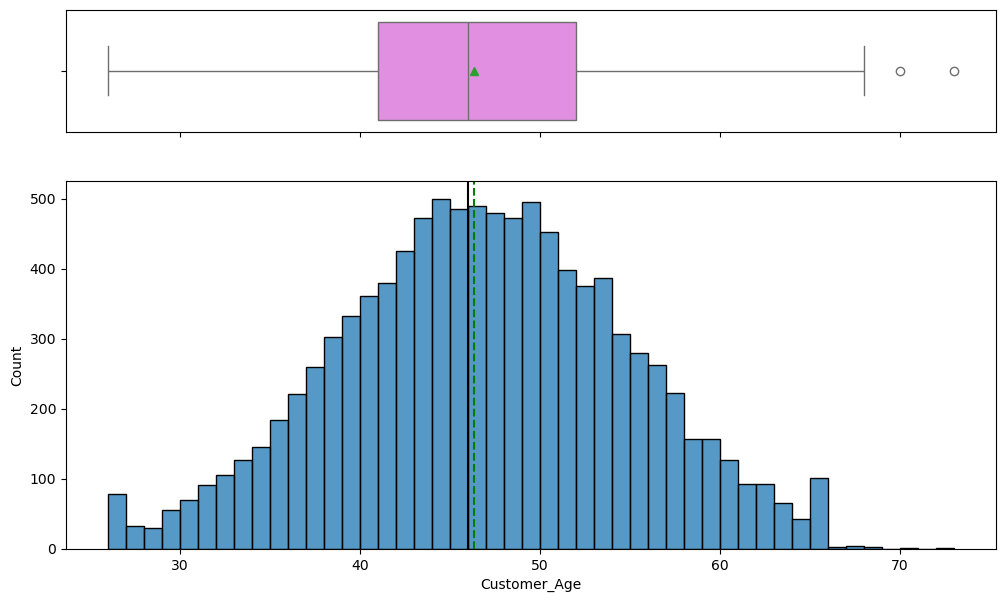

```python
histogram_boxplot(data, "Customer_Age")
```

- The ages are fairly normally distributed with a few outliers of older than 65 years; the mean and median are similar around 46 years old.
- About 50% of the customers are between 42 and 53 years old approximately.

#### Gender

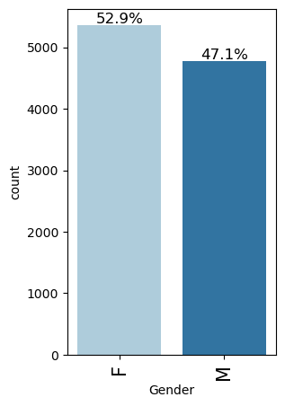

```python
labeled_barplot(data, "Gender", perc=True)
```

- The genders in the population are F and M for Female and Male, having 52.9% and 47.1% proportion respectively.
- There are more women than men in the dataset.

#### Dependent_count

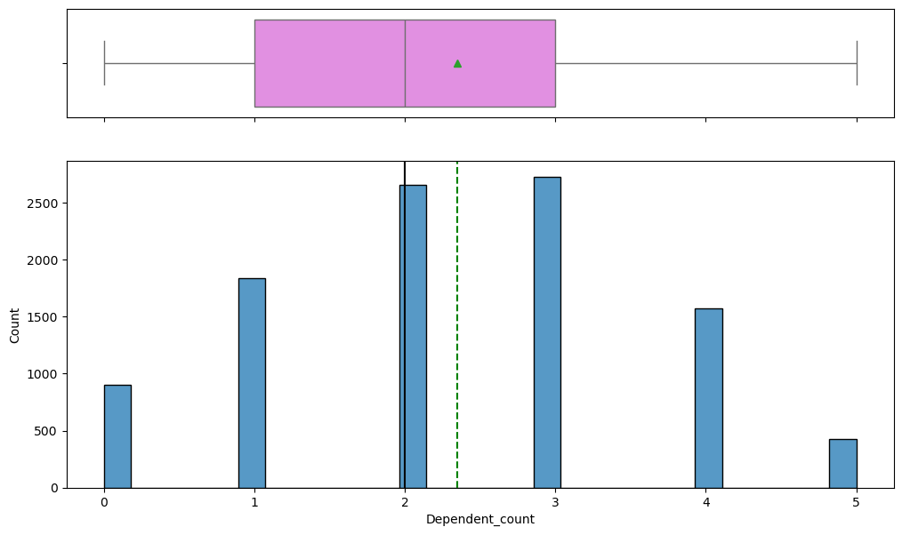

```python
histogram_boxplot(data, "Dependent_count")
```

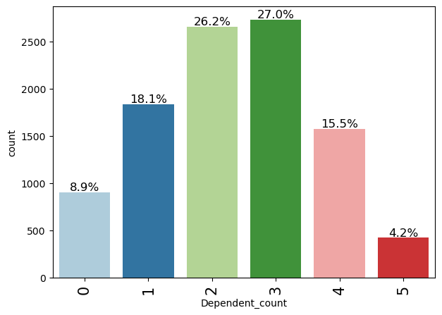

```python
labeled_barplot(data, "Dependent_count", perc=True)
```

- The dependent counts are only pure integer numbers between 0 and 5, with median at 2 and 50% of the population having between 1 to 3 dependents. There are a significant number of customers with 0 dependents influencing their financial needs or goals.
- The distribution is fairly symmetric with customers having 5 dependents being the lowest following by 0.
- Clients with dependent count with 5 are least occuring (4.2%) and those with 3 are most commonly occuring (27%). Since the data is not a continuous distribution, it is useful to see the percentage bar chart.

#### Education_Level

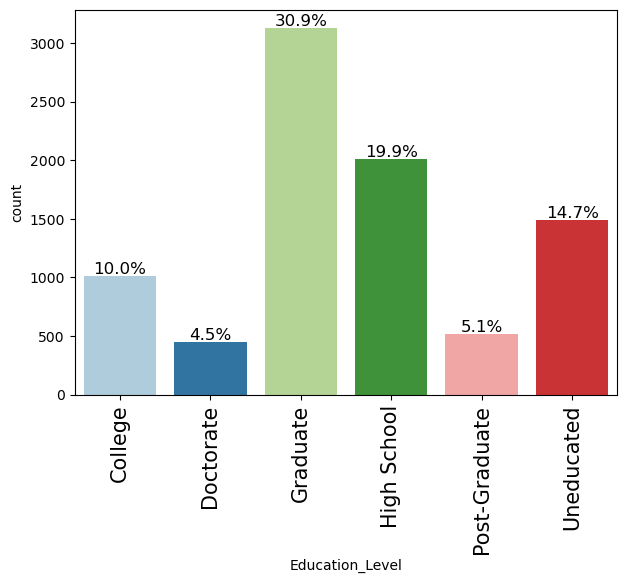

```python
labeled_barplot(data, "Education_Level", perc=True)
```

```python
#Value counts of education level with percentage
data["Education_Level"].value_counts(dropna=False)
```

```
Education_Level
Graduate         3128
High School      2013
NaN              1519
Uneducated       1487
College          1013
Post-Graduate     516
Doctorate         451
Name: count, dtype: int64
```

#### Marital_Status

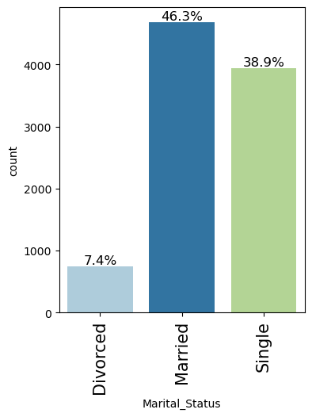

```python
labeled_barplot(data, "Marital_Status", perc=True)
```

- Most of the customers are married (46.3%) followed by single (38.9%) and the minority are divorced (7.4%)
- More than 85% of the population are either Married or Single.

#### Income_Category

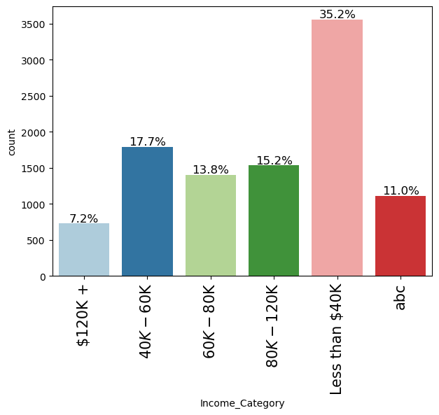

```python
labeled_barplot(data, "Income_Category", perc=True)
```

```python
# Inspect rows with income category as "abc"
data[data["Income_Category"]== "abc"]
```

|  | Attrition_Flag | Customer_Age | Gender | Dependent_count | Education_Level | Marital_Status | Income_Category | Card_Category | Months_on_book | Total_Relationship_Count | Months_Inactive_12_mon | Contacts_Count_12_mon | Credit_Limit | Total_Revolving_Bal | Avg_Open_To_Buy | Total_Amt_Chng_Q4_Q1 | Total_Trans_Amt | Total_Trans_Ct | Total_Ct_Chng_Q4_Q1 | Avg_Utilization_Ratio |
| --- | --- | --- | --- | --- | --- | --- | --- | --- | --- | --- | --- | --- | --- | --- | --- | --- | --- | --- | --- | --- |
| 19 | Existing Customer | 45 | F | 2 | Graduate | Married | abc | Blue | 37 | 6 | 1 | 2 | 14470.000 | 1157 | 13313.000 | 0.966 | 1207 | 21 | 0.909 | 0.080 |
| 28 | Existing Customer | 44 | F | 3 | Uneducated | Single | abc | Blue | 34 | 5 | 2 | 2 | 10100.000 | 0 | 10100.000 | 0.525 | 1052 | 18 | 1.571 | 0.000 |
| 39 | Attrited Customer | 66 | F | 0 | Doctorate | Married | abc | Blue | 56 | 5 | 4 | 3 | 7882.000 | 605 | 7277.000 | 1.052 | 704 | 16 | 0.143 | 0.077 |
| 44 | Existing Customer | 38 | F | 4 | Graduate | Single | abc | Blue | 28 | 2 | 3 | 3 | 9830.000 | 2055 | 7775.000 | 0.977 | 1042 | 23 | 0.917 | 0.209 |
| 58 | Existing Customer | 44 | F | 5 | Graduate | Married | abc | Blue | 35 | 4 | 1 | 2 | 6273.000 | 978 | 5295.000 | 2.275 | 1359 | 25 | 1.083 | 0.156 |
| ... | ... | ... | ... | ... | ... | ... | ... | ... | ... | ... | ... | ... | ... | ... | ... | ... | ... | ... | ... | ... |
| 10021 | Attrited Customer | 30 | F | 1 | Graduate | Married | abc | Blue | 18 | 4 | 1 | 4 | 4377.000 | 2517 | 1860.000 | 0.941 | 8759 | 74 | 0.609 | 0.575 |
| 10040 | Attrited Customer | 50 | F | 3 | Doctorate | Single | abc | Blue | 36 | 4 | 3 | 3 | 5173.000 | 0 | 5173.000 | 0.912 | 8757 | 68 | 0.789 | 0.000 |
| 10083 | Existing Customer | 42 | F | 4 | Uneducated | Married | abc | Blue | 23 | 4 | 1 | 2 | 8348.000 | 0 | 8348.000 | 0.695 | 15905 | 111 | 0.708 | 0.000 |
| 10092 | Attrited Customer | 40 | F | 3 | Graduate | Married | abc | Blue | 25 | 1 | 2 | 3 | 6888.000 | 1878 | 5010.000 | 1.059 | 9038 | 64 | 0.829 | 0.273 |
| 10119 | Attrited Customer | 55 | F | 3 | Uneducated | Single | abc | Blue | 47 | 4 | 3 | 3 | 14657.000 | 2517 | 12140.000 | 0.166 | 6009 | 53 | 0.514 | 0.172 |

1112 rows × 20 columns

```python
# Inspecting statistical summary of rows with income category as "abc" for any identifiable patterns
data[data["Income_Category"]== "abc"].describe(include="all").T
```

|  | count | unique | top | freq | mean | std | min | 25% | 50% | 75% | max |
| --- | --- | --- | --- | --- | --- | --- | --- | --- | --- | --- | --- |
| Attrition_Flag | 1112 | 2 | Existing Customer | 925 | NaN | NaN | NaN | NaN | NaN | NaN | NaN |
| Customer_Age | 1112.000 | NaN | NaN | NaN | 46.274 | 8.663 | 26.000 | 41.000 | 46.000 | 52.000 | 68.000 |
| Gender | 1112 | 2 | F | 1060 | NaN | NaN | NaN | NaN | NaN | NaN | NaN |
| Dependent_count | 1112.000 | NaN | NaN | NaN | 2.275 | 1.327 | 0.000 | 1.000 | 2.000 | 3.000 | 5.000 |
| Education_Level | 967 | 6 | Graduate | 332 | NaN | NaN | NaN | NaN | NaN | NaN | NaN |
| Marital_Status | 1030 | 3 | Married | 493 | NaN | NaN | NaN | NaN | NaN | NaN | NaN |
| Income_Category | 1112 | 1 | abc | 1112 | NaN | NaN | NaN | NaN | NaN | NaN | NaN |
| Card_Category | 1112 | 4 | Blue | 1045 | NaN | NaN | NaN | NaN | NaN | NaN | NaN |
| Months_on_book | 1112.000 | NaN | NaN | NaN | 35.754 | 8.479 | 13.000 | 31.000 | 36.000 | 40.000 | 56.000 |
| Total_Relationship_Count | 1112.000 | NaN | NaN | NaN | 3.815 | 1.541 | 1.000 | 3.000 | 4.000 | 5.000 | 6.000 |
| Months_Inactive_12_mon | 1112.000 | NaN | NaN | NaN | 2.374 | 1.051 | 0.000 | 2.000 | 2.000 | 3.000 | 6.000 |
| Contacts_Count_12_mon | 1112.000 | NaN | NaN | NaN | 2.462 | 1.093 | 0.000 | 2.000 | 2.000 | 3.000 | 6.000 |
| Credit_Limit | 1112.000 | NaN | NaN | NaN | 9516.582 | 8677.922 | 1438.300 | 3137.000 | 6380.000 | 12420.250 | 34516.000 |
| Total_Revolving_Bal | 1112.000 | NaN | NaN | NaN | 1115.065 | 829.245 | 0.000 | 0.000 | 1243.000 | 1785.500 | 2517.000 |
| Avg_Open_To_Buy | 1112.000 | NaN | NaN | NaN | 8401.518 | 8668.534 | 14.000 | 1952.250 | 5464.500 | 11378.250 | 34516.000 |
| Total_Amt_Chng_Q4_Q1 | 1112.000 | NaN | NaN | NaN | 0.765 | 0.215 | 0.010 | 0.644 | 0.742 | 0.868 | 2.675 |
| Total_Trans_Amt | 1112.000 | NaN | NaN | NaN | 4282.211 | 2922.695 | 644.000 | 2452.750 | 4107.000 | 4725.000 | 16908.000 |
| Total_Trans_Ct | 1112.000 | NaN | NaN | NaN | 66.251 | 21.660 | 14.000 | 48.000 | 69.000 | 81.000 | 138.000 |
| Total_Ct_Chng_Q4_Q1 | 1112.000 | NaN | NaN | NaN | 0.718 | 0.244 | 0.000 | 0.583 | 0.704 | 0.824 | 3.571 |
| Avg_Utilization_Ratio | 1112.000 | NaN | NaN | NaN | 0.221 | 0.245 | 0.000 | 0.000 | 0.125 | 0.351 | 0.992 |

```python
#Set all income category abc as null so that they can be considered as missing values and imputed later
data.loc[data["Income_Category"]== "abc", "Income_Category"] = np.nan
```

#### Card_Category

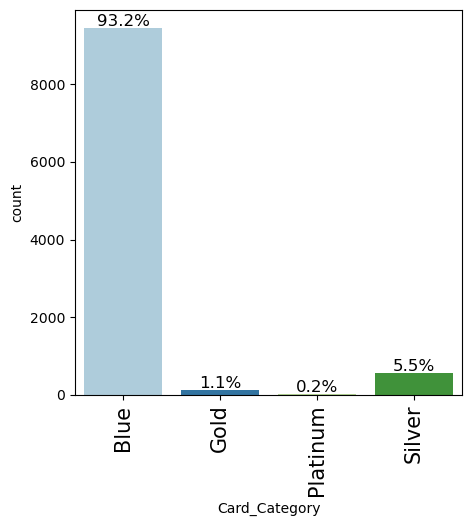

```python
labeled_barplot(data, "Card_Category", perc=True)
```

```python
data["Card_Category"].value_counts()
```

```
Card_Category
Blue        9436
Silver       555
Gold         116
Platinum      20
Name: count, dtype: int64
```

- The vast majority of customers hold a credit card in the Blue Category (93.2%), while 5.5% are Silver card holders, only 1.1% are Gold card holders and only 0.2% or 20 customers hold a Platinum card.

#### Months_on_book

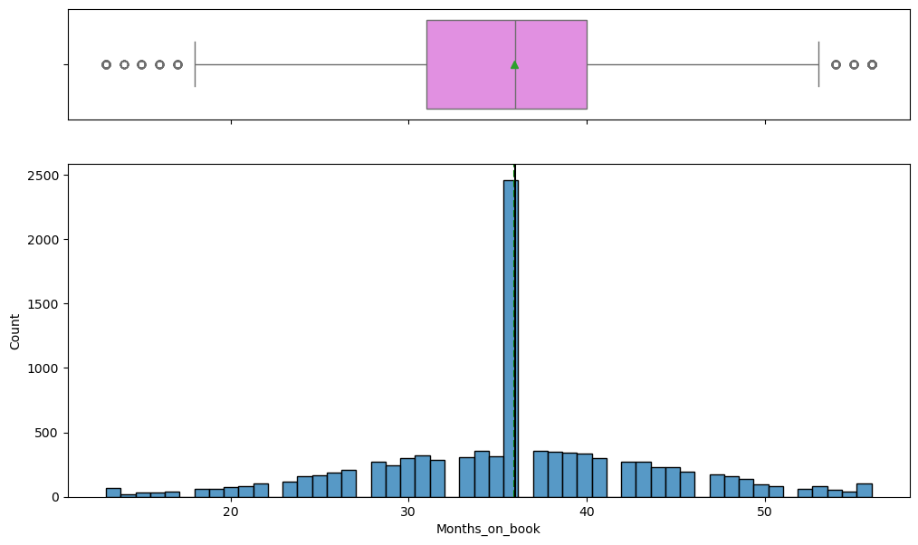

```python
histogram_boxplot(data, "Months_on_book")
```

```python
# Analyzing the distribution of the customers with months on book 36 months
data[data["Months_on_book"]==36].describe(include="all").T
```

|  | count | unique | top | freq | mean | std | min | 25% | 50% | 75% | max |
| --- | --- | --- | --- | --- | --- | --- | --- | --- | --- | --- | --- |
| Attrition_Flag | 2463 | 2 | Existing Customer | 2033 | NaN | NaN | NaN | NaN | NaN | NaN | NaN |
| Customer_Age | 2463.000 | NaN | NaN | NaN | 46.156 | 7.607 | 26.000 | 41.000 | 46.000 | 51.000 | 73.000 |
| Gender | 2463 | 2 | F | 1364 | NaN | NaN | NaN | NaN | NaN | NaN | NaN |
| Dependent_count | 2463.000 | NaN | NaN | NaN | 2.405 | 1.304 | 0.000 | 1.000 | 2.000 | 3.000 | 5.000 |
| Education_Level | 2076 | 6 | Graduate | 729 | NaN | NaN | NaN | NaN | NaN | NaN | NaN |
| Marital_Status | 2271 | 3 | Married | 1125 | NaN | NaN | NaN | NaN | NaN | NaN | NaN |
| Income_Category | 2187 | 5 | Less than $40K | 944 | NaN | NaN | NaN | NaN | NaN | NaN | NaN |
| Card_Category | 2463 | 4 | Blue | 2293 | NaN | NaN | NaN | NaN | NaN | NaN | NaN |
| Months_on_book | 2463.000 | NaN | NaN | NaN | 36.000 | 0.000 | 36.000 | 36.000 | 36.000 | 36.000 | 36.000 |
| Total_Relationship_Count | 2463.000 | NaN | NaN | NaN | 3.782 | 1.563 | 1.000 | 3.000 | 4.000 | 5.000 | 6.000 |
| Months_Inactive_12_mon | 2463.000 | NaN | NaN | NaN | 2.346 | 0.966 | 0.000 | 2.000 | 2.000 | 3.000 | 6.000 |
| Contacts_Count_12_mon | 2463.000 | NaN | NaN | NaN | 2.428 | 1.105 | 0.000 | 2.000 | 2.000 | 3.000 | 6.000 |
| Credit_Limit | 2463.000 | NaN | NaN | NaN | 8505.956 | 9115.601 | 1438.300 | 2516.000 | 4375.000 | 10554.500 | 34516.000 |
| Total_Revolving_Bal | 2463.000 | NaN | NaN | NaN | 1151.959 | 824.045 | 0.000 | 0.000 | 1264.000 | 1778.000 | 2517.000 |
| Avg_Open_To_Buy | 2463.000 | NaN | NaN | NaN | 7353.998 | 9112.363 | 10.000 | 1283.500 | 3316.000 | 9463.500 | 34516.000 |
| Total_Amt_Chng_Q4_Q1 | 2463.000 | NaN | NaN | NaN | 0.755 | 0.223 | 0.000 | 0.627 | 0.733 | 0.853 | 3.397 |
| Total_Trans_Amt | 2463.000 | NaN | NaN | NaN | 4498.042 | 3452.388 | 510.000 | 2171.500 | 3978.000 | 4784.500 | 18484.000 |
| Total_Trans_Ct | 2463.000 | NaN | NaN | NaN | 65.210 | 23.541 | 10.000 | 45.000 | 68.000 | 81.000 | 134.000 |
| Total_Ct_Chng_Q4_Q1 | 2463.000 | NaN | NaN | NaN | 0.713 | 0.245 | 0.000 | 0.579 | 0.698 | 0.820 | 3.250 |
| Avg_Utilization_Ratio | 2463.000 | NaN | NaN | NaN | 0.277 | 0.279 | 0.000 | 0.000 | 0.178 | 0.504 | 0.995 |

- The distribution of the period of relationship with the bank is mostly normally distributed, with a few outliers on both sides, but with a concentration in the middle.
- 36 months or 3 years is the most commonly occurring value by far with 2463 clients. This may indicate that 36 months could be key milestone influenced by the banks policies and strategies.
- No specific patterns to be noted in the customers with 36 months on book i.e. months on book doesn't seem to be determined by any other customer attribute at a glance.

#### Total_Relationship_Count

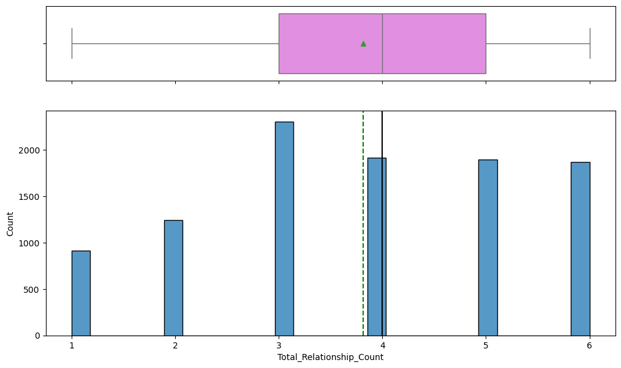

```python
histogram_boxplot(data, "Total_Relationship_Count")
```

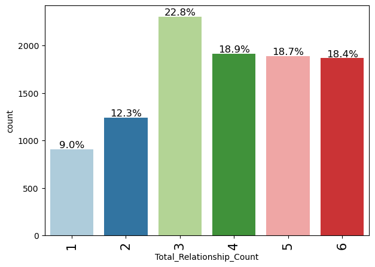

```python
labeled_barplot(data, "Total_Relationship_Count", perc=True)
```

- The number of products owned by the customers is between 1 and 6 and is not a continuous number, though the median is 4 and 50% of the customers own between 3 to 5 products.
- It is also useful to see the percentage distribution of this column, and we can see that 22.8% of the customers own 3 products whereas the customers with 4,5 or 6 products are all about 18%, and the least number of customers own only 1 product.
- In general customers tend to own higher number of products and the relationship between this value and Attrition will be very interesting to investigate.

#### Months_Inactive_12_mon

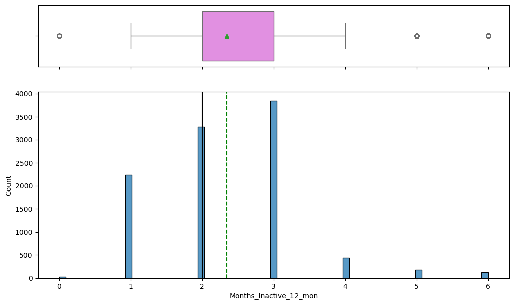

```python
histogram_boxplot(data, "Months_Inactive_12_mon")
```

- The median number of inactive months in the last 12 months is 2, and 50% of the customers have between 2 to 3 inactive months.
- The values are not continuous but in general 75% of the customers have 4 or less inactive months in the last 12 months.
- Only a small proportion of customers have been inactive for 0 months, and none have been inactive for more than 6 months.

#### Contacts_Count_12_mon

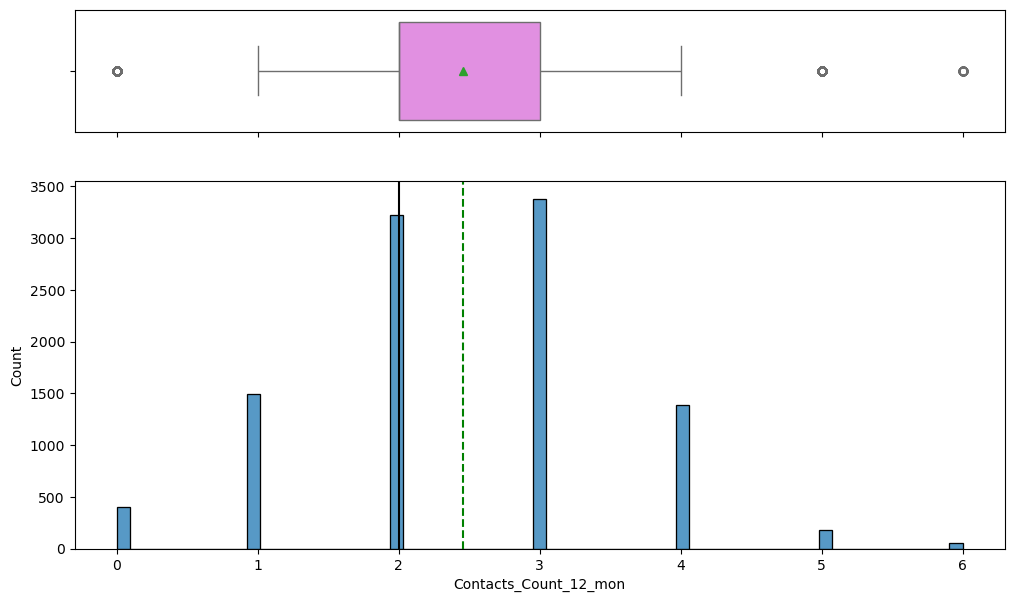

```python
histogram_boxplot(data, "Contacts_Count_12_mon")
```

- The median number of contacts between the customer and the bank in the last 12 months is 2, and the distribution is fairly normally distributed despite being discrete.
- 50% of the customers have between 2 to 3 contacts in the last 12 months, while the fewest customers have had 5 or 6 contacts.

#### Credit_Limit

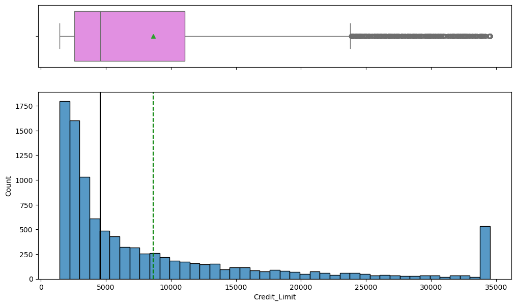

```python
histogram_boxplot(data, "Credit_Limit")
```

- Credit_Limit is a heavily right skewed distribution, with a large concentration of customers having lower credit limits, while a small group has significantly higher limits.
- The distribution has many outliers in the credit limits above around 24000 extending up to 35000.
- The median value is about 4000 and 75% of the customers have a credit limit of about 11000 or less.

#### Total_Revolving_Bal

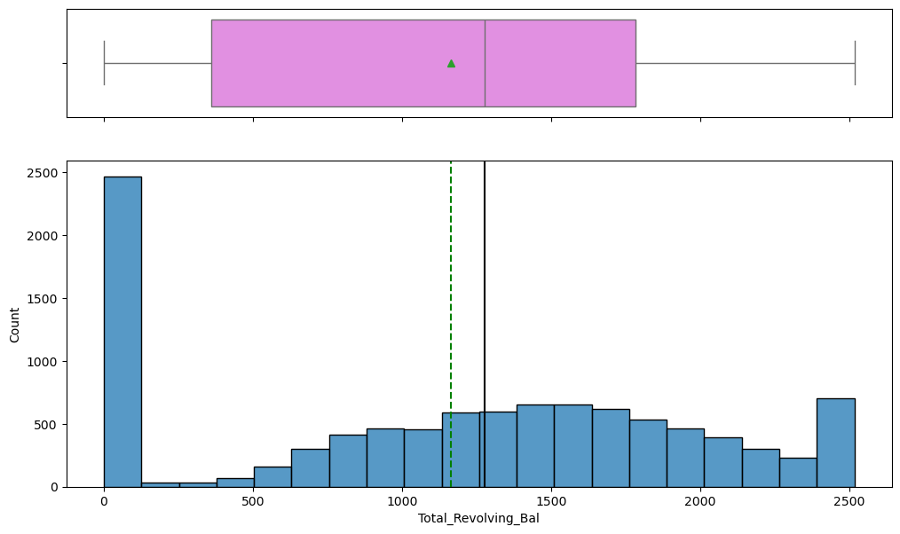

```python
histogram_boxplot(data, "Total_Revolving_Bal")
```

#### Avg_Open_To_Buy

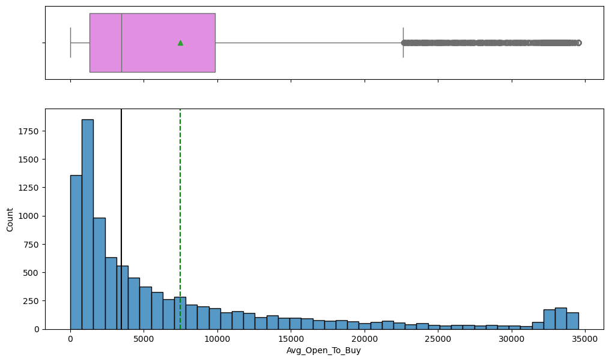

```python
histogram_boxplot(data, "Avg_Open_To_Buy")
```

- The open to buy credit line average of the last 12 is very right skewed with some customers are outliers in the upper range. 75% of customers recorded an average of 10000 or less.
- There are many outliers in the upper range which suggest that there isa group of customers with very high open to buy credit line average.

#### Total_Trans_Amt

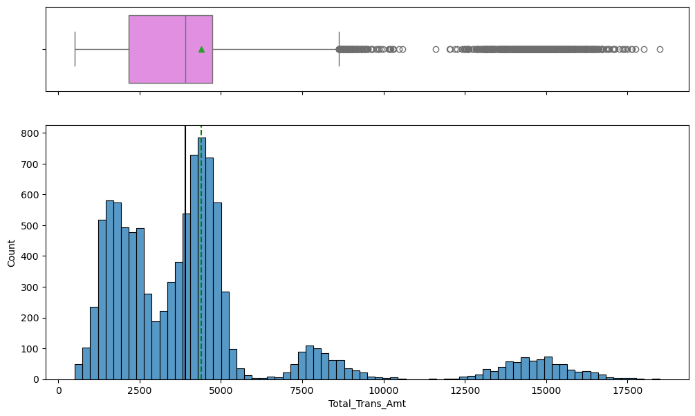

```python
histogram_boxplot(data, "Total_Trans_Amt")
```

- The total transaction amount of the last 12 months is right skewed but an atypical distribution with median around 4000 dollars and many outliers extending up to 18000.
- Majority of the customers have a total transaction amount the lower range but this is not without exceptions.
- 75% of the customers have total transaction amount of 5000 or less.

#### Total_Trans_Ct

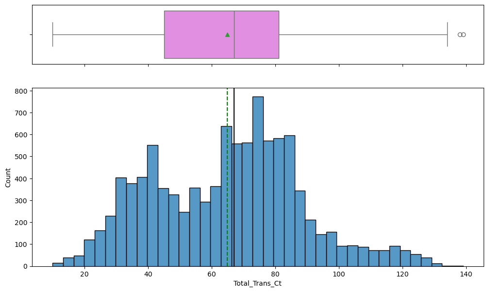

```python
histogram_boxplot(data, "Total_Trans_Ct")
```

- The total transaction count is a normal distribution with just two outliers above 130 transactions, whereas the median is about 67.
- 50% of the customers have a total transaction count between 42 and 80 in the last 12 months.

#### Total_Ct_Chng_Q4_Q1

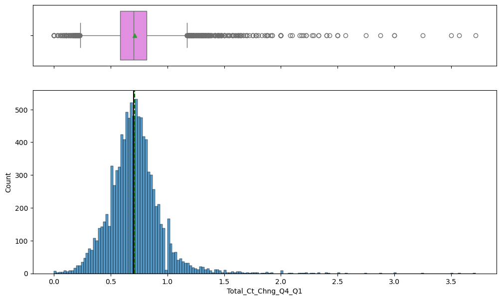

```python
histogram_boxplot(data, "Total_Ct_Chng_Q4_Q1")
```

- Total change in transaction count is very heavily right skewed, with many outliers in the higher range but also some in the lower range which indicates relatively stable transaction changes between the two quarters.
- 50% of the customers have this ratio between 0.6 and 0.8, whereas some outliers go all the way above 3.5. The customers with the ratio above 3.5 showed significant increase in their transaction behavior.

#### Total_Amt_Chng_Q4_Q1

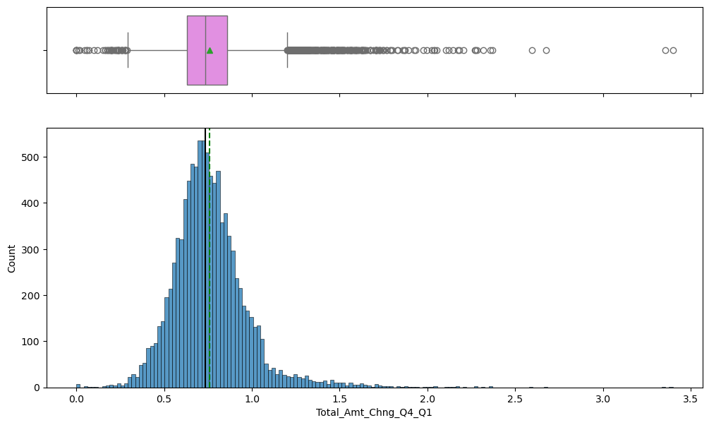

```python
histogram_boxplot(data, "Total_Amt_Chng_Q4_Q1")
```

- Total amount change has a very similar distribution to total count change, which intuitively makes sense because the number of transactions could be positively correlated to the total amount.
- Total amount change between Q4 and Q1 is also right skewed with many outliers, with 75% of the customers having this ratio at or below 0.8

#### Avg_Utilization_Ratio

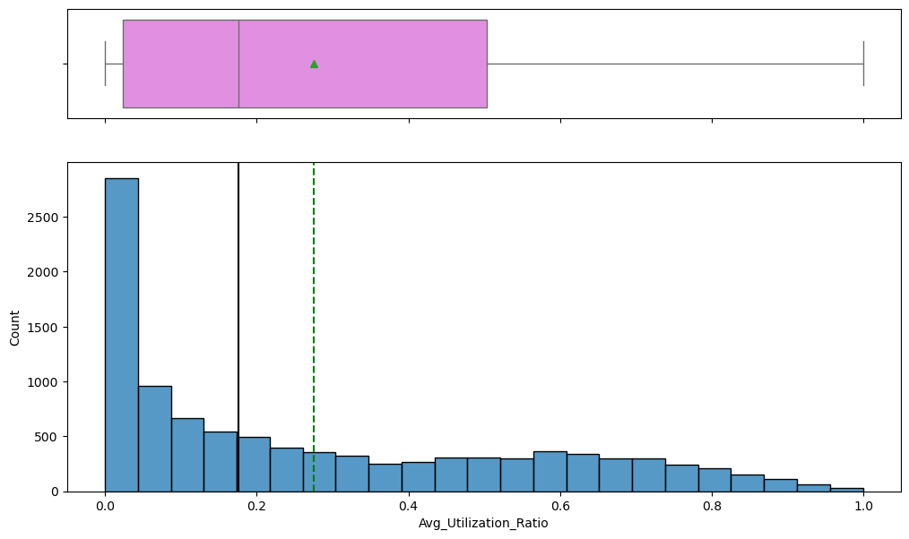

```python
histogram_boxplot(data, "Avg_Utilization_Ratio")
```

- Average utilization ratio is more right skewed, while many customers have 0 as the ratio, 75% of them have a ratio of less than 0.5 indicating lower credit usage for most.
- Avg Utilization Ratio is a mathematical function of Avg_Open_To_Buy and Credit_Limit, which are both right skewed distributions, hence it makes sense that the ratio is also similar.

#### Attrition_Flag

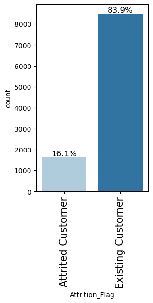

```python
labeled_barplot(data, "Attrition_Flag", perc=True)
```

- The attrition flag is the value we want to predict, and from the given data 16.1% customers have attrited and 83.9% are existing.
- There are many more existing customers than attrited customers, the weight of which must be taken into account when building the model.
- These values can be encoded before proceeding.

```python
# Encode attrition flag values to 0 and 1
data["Attrition_Flag"] = data["Attrition_Flag"].map({"Existing Customer": 0, "Attrited Customer": 1})
```

#### Univariate questions

**1. How is the total transaction amount distributed?**

- The total transaction amount of the last 12 months is right skewed but an atypical distribution with median around 4000 dollars and many outliers.
- 75% of the customers have total transaction amount of 5000 or less.

**2. What is the distribution of the level of education of customers?**

- The distribution of Education Level shows that the majority of customers are Graduates (30.9%), followed by High School (19.9%) and Uneducated (14.7%), with smaller proportions holding College (10%), Post-Graduate (5.1%), and Doctorate (4.5%) degrees.

**3. What is the distribution of the level of income of customers?**

- Most customers (35.2%) fall in the income range of less than 40K, followed by 40K-60K with 17.7%, 15.2% in the 80K-120K bracket, 13.8% in the 60K-80K range and the least number in the highest income range of 120K+. This is generally consistent with the intuitive distribution of income in a general population.

### Bivariate Analysis

#### Correlation Observations

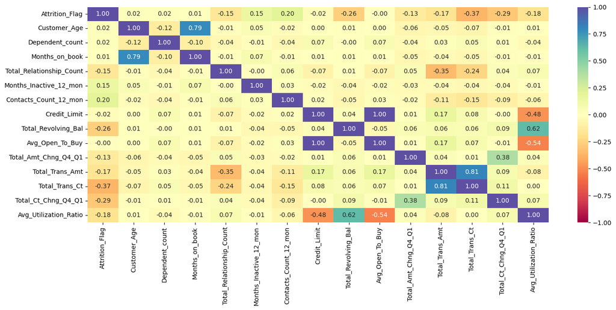

```python
#Correlation heatmap to analyze relationship between all numerical variables
cols_list = data.select_dtypes(include=np.number).columns.tolist()
plt.figure(figsize=(15, 7))
sns.heatmap(
    data[cols_list].corr(), annot=True, vmin=-1, vmax=1, fmt=".2f", cmap="Spectral"
)
plt.tight_layout()
plt.show()
```

From the correlation matrix, we can see several strong correlations and some weak ones. Below is a summary by column:

- Attrition Flag: We are most interested in seeing which columns are strongly correlated with this value because it is our dependent variable.
  - Total_Trans_Ct: The strongest negative correlation with attrition meaning that higher the total transaction count, less likely they are to attrite but the correlation is only -0.37.
  - Total_Ct_Chng_Q4_Q1: The correlation is -0.29 which suggests that customers with a higher change in transaction count between Q4 and Q1 are less likely to attrite.
  - Total_Revolving_Bal: With a correlation of -0.26, this suggests that customers with a higher revolving balance are less likely to attrite.
  - Contacts_Count_12_mon: Positively correlated (0.20) indicating that the more contacts the customer had with the bank in the last 12 months, the more likely they are to attrite, which is strange but could indicate dissatisfaction of service.

  The Attrition Flag seems to have a handful of weak to medium influencing variables, a combination of which is likely to give the best outcome when we build the model.
- Customer Age has a very strong correlation of 0.79 with months on book, which is as expected since the older customers tend to have a long relationship with the bank.
- Credit Limit and Avg Open to Buy have a perfect correlation of 1.00, which is understandable and makes sense since Avg Open to Buy must be derived from the available credit, hence it is a function of the Credit Limit.
- Total Transaction Amount and Total Transaction Count have a positive correlation of 0.81. This logically makes sense since the higher the number of transactions, the higher the total transaction amount tends to be.
- Total Revolving Balance and Avg Utilization Ratio have a positive correlation of 0.62, indicating that customers that have a higher balance also have a higher utilization rate.
- Avg Utilization Ratio is also fairly strongly negatively correlated with Credit_Limit (-0.48) and Avg_Open_To_Buy (-0.54) which is expected since they are related mathematically and are a function of how much credit limit is used.

#### Relationship of various columns with Attrition Flag (target variable)

##### Attrition_Flag vs Gender

```
Attrition_Flag     0     1    All
Gender
All             8500  1627  10127
F               4428   930   5358
M               4072   697   4769
------------------------------------------------------------------------------------------------------------------------
```

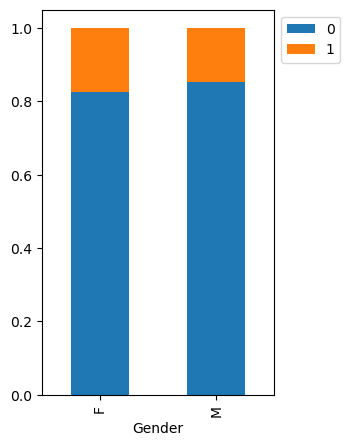

```python
stacked_barplot(data, "Gender", "Attrition_Flag")
```

- Among the females, 4428 remain existing customers while 930 have attrited. Among the males, 4072 remain existing customers and 697 have attrited. There are total 5358 females and 4769 males in the dataset.
- The female attrition rate is slightly higher (17.4%) than the male attrition rate (14.6%). Though the total number of females are higher, the rate of attrition seems to be higher in females too by a small margin. In both genders, majority of customers are existing customers.

##### Attrition_Flag vs Marital_Status

```
Attrition_Flag     0     1   All
Marital_Status
All             7880  1498  9378
Married         3978   709  4687
Single          3275   668  3943
Divorced         627   121   748
------------------------------------------------------------------------------------------------------------------------
```

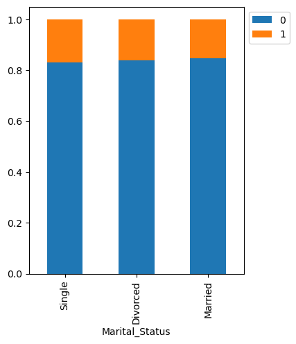

```python
stacked_barplot(data, "Marital_Status", "Attrition_Flag")
```

##### Attrition_Flag vs Education_Level

```
Attrition_Flag      0     1   All
Education_Level
All              7237  1371  8608
Graduate         2641   487  3128
High School      1707   306  2013
Uneducated       1250   237  1487
College           859   154  1013
Doctorate         356    95   451
Post-Graduate     424    92   516
------------------------------------------------------------------------------------------------------------------------
```

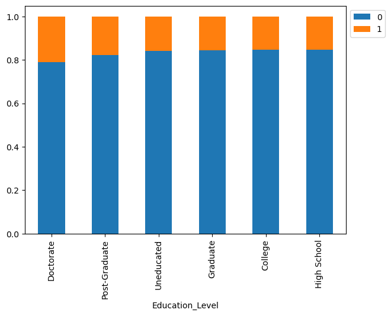

```python
stacked_barplot(data, "Education_Level", "Attrition_Flag")
```

##### Attrition_Flag vs Income_Category

```
Attrition_Flag      0     1   All
Income_Category
All              7575  1440  9015
Less than $40K   2949   612  3561
$40K - $60K      1519   271  1790
$80K - $120K     1293   242  1535
$60K - $80K      1213   189  1402
$120K +           601   126   727
------------------------------------------------------------------------------------------------------------------------
```

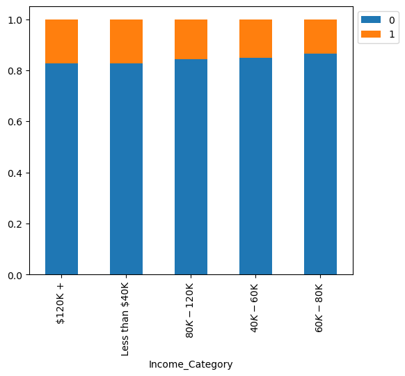

```python
stacked_barplot(data, "Income_Category", "Attrition_Flag")
```

##### Attrition_Flag vs Card_Category

```
Attrition_Flag     0     1    All
Card_Category
All             8500  1627  10127
Blue            7917  1519   9436
Silver           473    82    555
Gold              95    21    116
Platinum          15     5     20
------------------------------------------------------------------------------------------------------------------------
```

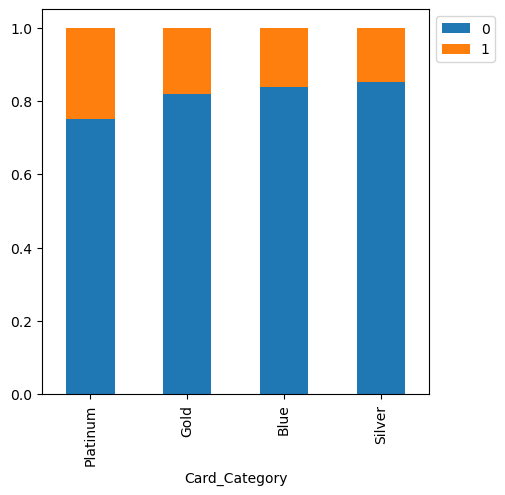

```python
stacked_barplot(data, "Card_Category", "Attrition_Flag")
```

- The attrition rate of blue cardholders is 16.09% which is close to and heavily influences the overall attrition rate.
- Platinum cardholders have a high attrition rate of 25% but since the number of customers is only 20, it must be taken with a grain of salt. However it is worthwhile noting that in the higher customer income category and highest card category, the attrition rate is generally higher which indicates dissatisfaction among higher paying customers.
- Gold cardholders have an attrition rate of 18.10%, but also represents a very small part of the customers.
- Silver cardholders have an attrition rate of 14.77% which is the lowest among all card categories.
- While there are small differences in attrition vs retention among different data groups, the large difference in population sizes of the different card categories may affect how influential this column is in predicting attrition.

##### Attrition_Flag vs Dependent_count

```
Attrition_Flag      0     1    All
Dependent_count
All              8500  1627  10127
3                2250   482   2732
2                2238   417   2655
1                1569   269   1838
4                1314   260   1574
0                 769   135    904
5                 360    64    424
------------------------------------------------------------------------------------------------------------------------
```

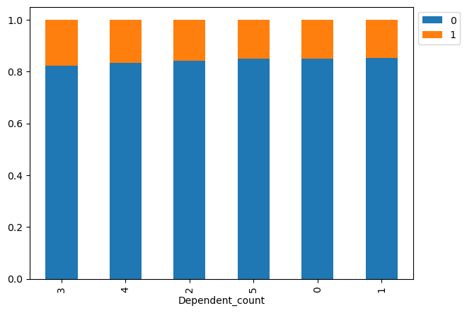

```python
stacked_barplot(data, "Dependent_count", "Attrition_Flag")
```

##### Attrition_Flag vs Months_Inactive_12_mon

```
Attrition_Flag             0     1    All
Months_Inactive_12_mon
All                     8500  1627  10127
3                       3020   826   3846
2                       2777   505   3282
4                        305   130    435
1                       2133   100   2233
5                        146    32    178
6                        105    19    124
0                         14    15     29
------------------------------------------------------------------------------------------------------------------------
```

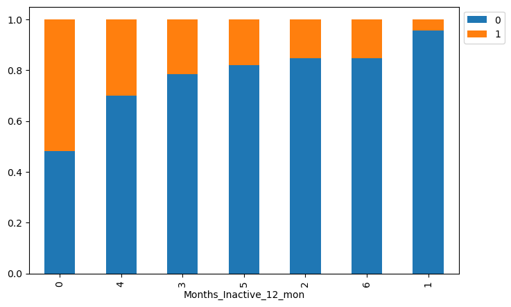

```python
stacked_barplot(data, "Months_Inactive_12_mon", "Attrition_Flag")
```

- There are various patterns here that describe the relationship between number of inactive months in the last 12 months and attrition. Customers that have 0, 3, 4 and 5 months are more likely to attrite, whereas customers with 1 month inactive are much more likely to continue being customers.
- There is no linear correlation between the two from which we can say for example that higher the number of inactive months, the more likely to attrite, but in seems that in general those that have 3-5 months of inactivity tend to attrite, whereas very high months of inactivity does not necessary mean attrition.
- This is likely a very useful variable in combination with others to determine attrition.

##### Attrition_Flag vs Contacts_Count_12_mon

```
Attrition_Flag            0     1    All
Contacts_Count_12_mon
All                    8500  1627  10127
3                      2699   681   3380
2                      2824   403   3227
4                      1077   315   1392
1                      1391   108   1499
5                       117    59    176
6                         0    54     54
0                       392     7    399
------------------------------------------------------------------------------------------------------------------------
```

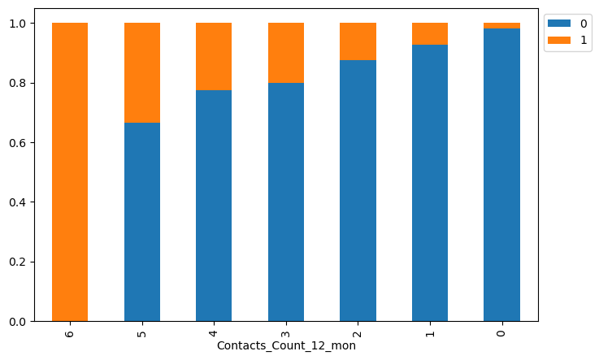

```python
stacked_barplot(data, "Contacts_Count_12_mon", "Attrition_Flag")
```

- From the stacked barplot, we can see that customers with lower number of contacts (0, 1 and 2) are less likely to attrite, whereas customers with higher number of contacts in the last 12 months (3, 4, 5 and 6) are much more likely to attrite.
- This is counter intuitive but it could indicate that there is a certain level of dissatisfaction with the service and hence more the interactions, more likely they are to be an attriting customer.
- This variable seems to be a good indicator for attrition, though the differences aren't necessarily massive and may need to be combined with other values. It is also worth noting the small population size of the customers with 6 contact counts in the last 12 months.